# Unsupervised Learning: Trade&Ahead

**Marks: 60**

## Context

The stock market has consistently proven to be a good place to invest in and save for the future. There are a lot of compelling reasons to invest in stocks. It can help in fighting inflation, create wealth, and also provides some tax benefits. Good steady returns on investments over a long period of time can also grow a lot more than seems possible. Also, thanks to the power of compound interest, the earlier one starts investing, the larger the corpus one can have for retirement. Overall, investing in stocks can help meet life's financial aspirations.

It is important to maintain a diversified portfolio when investing in stocks in order to maximise earnings under any market condition. Having a diversified portfolio tends to yield higher returns and face lower risk by tempering potential losses when the market is down. It is often easy to get lost in a sea of financial metrics to analyze while determining the worth of a stock, and doing the same for a multitude of stocks to identify the right picks for an individual can be a tedious task. By doing a cluster analysis, one can identify stocks that exhibit similar characteristics and ones which exhibit minimum correlation. This will help investors better analyze stocks across different market segments and help protect against risks that could make the portfolio vulnerable to losses.

## Objective

Trade&Ahead is a financial consultancy firm who provide their customers with personalized investment strategies. They have hired you as a Data Scientist and provided you with data comprising stock price and some financial indicators for a few companies listed under the New York Stock Exchange. They have assigned you the tasks of analyzing the data, grouping the stocks based on the attributes provided, and sharing insights about the characteristics of each group.

### Data Dictionary

- Ticker Symbol: An abbreviation used to uniquely identify publicly traded shares of a particular stock on a particular stock market
- Company: Name of the company
- GICS Sector: The specific economic sector assigned to a company by the Global Industry Classification Standard (GICS) that best defines its business operations
- GICS Sub Industry: The specific sub-industry group assigned to a company by the Global Industry Classification Standard (GICS) that best defines its business operations
- Current Price: Current stock price in dollars
- Price Change: Percentage change in the stock price in 13 weeks
- Volatility: Standard deviation of the stock price over the past 13 weeks
- ROE: A measure of financial performance calculated by dividing net income by shareholders' equity (shareholders' equity is equal to a company's assets minus its debt)
- Cash Ratio: The ratio of a company's total reserves of cash and cash equivalents to its total current liabilities
- Net Cash Flow: The difference between a company's cash inflows and outflows (in dollars)
- Net Income: Revenues minus expenses, interest, and taxes (in dollars)
- Earnings Per Share: Company's net profit divided by the number of common shares it has outstanding (in dollars)
- Estimated Shares Outstanding: Company's stock currently held by all its shareholders
- P/E Ratio: Ratio of the company's current stock price to the earnings per share
- P/B Ratio: Ratio of the company's stock price per share by its book value per share (book value of a company is the net difference between that company's total assets and total liabilities)

## Importing necessary libraries and data

```python
import numpy as np
import pandas as pd
import matplotlib.pyplot as plt
import seaborn as sns

# to suppress warnings
import warnings
warnings.filterwarnings("ignore")

# set style
sns.set_theme(style='darkgrid')

# data scaling
from sklearn.preprocessing import StandardScaler

# to compute distances
from scipy.spatial.distance import cdist, pdist

# k-means clustering and silhouette scores
from sklearn.cluster import KMeans
from sklearn.metrics import silhouette_score

# visualize the elbow curve and silhouette score
from yellowbrick.cluster import KElbowVisualizer, SilhouetteVisualizer

# hierarchical clustering, cophenetic correlation and dendrograms
from sklearn.cluster import AgglomerativeClustering
from scipy.cluster.hierarchy import dendrogram, linkage, cophenet
```

## Data Overview

- Observations
- Sanity checks

```python
from google.colab import files
uploaded = files.upload()
```

Upload widget is only available when the cell has been executed in the current browser session. Please rerun this cell to enable.

```
Saving stock_data.csv to stock_data (1).csv
```

```python
df = pd.read_csv('stock_data.csv')
```

```python
df.info()
```

```
<class 'pandas.core.frame.DataFrame'>
RangeIndex: 340 entries, 0 to 339
Data columns (total 15 columns):
 #   Column                        Non-Null Count  Dtype
---  ------                        --------------  -----
 0   Ticker Symbol                 340 non-null    object
 1   Security                      340 non-null    object
 2   GICS Sector                   340 non-null    object
 3   GICS Sub Industry             340 non-null    object
 4   Current Price                 340 non-null    float64
 5   Price Change                  340 non-null    float64
 6   Volatility                    340 non-null    float64
 7   ROE                           340 non-null    int64
 8   Cash Ratio                    340 non-null    int64
 9   Net Cash Flow                 340 non-null    int64
 10  Net Income                    340 non-null    int64
 11  Earnings Per Share            340 non-null    float64
 12  Estimated Shares Outstanding  340 non-null    float64
 13  P/E Ratio                     340 non-null    float64
 14  P/B Ratio                     340 non-null    float64
dtypes: float64(7), int64(4), object(4)
memory usage: 40.0+ KB
```

```python
df.head()
```

|  | Ticker Symbol | Security | GICS Sector | GICS Sub Industry | Current Price | Price Change | Volatility | ROE | Cash Ratio | Net Cash Flow | Net Income | Earnings Per Share | Estimated Shares Outstanding | P/E Ratio | P/B Ratio |
| --- | --- | --- | --- | --- | --- | --- | --- | --- | --- | --- | --- | --- | --- | --- | --- |
| 0 | AAL | American Airlines Group | Industrials | Airlines | 42.349998 | 9.999995 | 1.687151 | 135 | 51 | -604000000 | 7610000000 | 11.39 | 6.681299e+08 | 3.718174 | -8.784219 |
| 1 | ABBV | AbbVie | Health Care | Pharmaceuticals | 59.240002 | 8.339433 | 2.197887 | 130 | 77 | 51000000 | 5144000000 | 3.15 | 1.633016e+09 | 18.806350 | -8.750068 |
| 2 | ABT | Abbott Laboratories | Health Care | Health Care Equipment | 44.910000 | 11.301121 | 1.273646 | 21 | 67 | 938000000 | 4423000000 | 2.94 | 1.504422e+09 | 15.275510 | -0.394171 |
| 3 | ADBE | Adobe Systems Inc | Information Technology | Application Software | 93.940002 | 13.977195 | 1.357679 | 9 | 180 | -240840000 | 629551000 | 1.26 | 4.996437e+08 | 74.555557 | 4.199651 |
| 4 | ADI | Analog Devices, Inc. | Information Technology | Semiconductors | 55.320000 | -1.827858 | 1.701169 | 14 | 272 | 315120000 | 696878000 | 0.31 | 2.247994e+09 | 178.451613 | 1.059810 |

```python
df.shape
```

```
(340, 15)
```

```python
df.isna().sum()
```

```
Ticker Symbol                   0
Security                        0
GICS Sector                     0
GICS Sub Industry               0
Current Price                   0
Price Change                    0
Volatility                      0
ROE                             0
Cash Ratio                      0
Net Cash Flow                   0
Net Income                      0
Earnings Per Share              0
Estimated Shares Outstanding    0
P/E Ratio                       0
P/B Ratio                       0
dtype: int64
```

```python
df.duplicated().sum()
```

```
0
```

## Exploratory Data Analysis (EDA)

- EDA is an important part of any project involving data.
- It is important to investigate and understand the data better before building a model with it.
- A few questions have been mentioned below which will help you approach the analysis in the right manner and generate insights from the data.
- A thorough analysis of the data, in addition to the questions mentioned below, should be done.

```python
df.describe(include='all').T
```

|  | count | unique | top | freq | mean | std | min | 25% | 50% | 75% | max |
| --- | --- | --- | --- | --- | --- | --- | --- | --- | --- | --- | --- |
| Ticker Symbol | 340 | 340 | AAL | 1 | NaN | NaN | NaN | NaN | NaN | NaN | NaN |
| Security | 340 | 340 | American Airlines Group | 1 | NaN | NaN | NaN | NaN | NaN | NaN | NaN |
| GICS Sector | 340 | 11 | Industrials | 53 | NaN | NaN | NaN | NaN | NaN | NaN | NaN |
| GICS Sub Industry | 340 | 104 | Oil & Gas Exploration & Production | 16 | NaN | NaN | NaN | NaN | NaN | NaN | NaN |
| Current Price | 340.0 | NaN | NaN | NaN | 80.862345 | 98.055086 | 4.5 | 38.555 | 59.705 | 92.880001 | 1274.949951 |
| Price Change | 340.0 | NaN | NaN | NaN | 4.078194 | 12.006338 | -47.129693 | -0.939484 | 4.819505 | 10.695493 | 55.051683 |
| Volatility | 340.0 | NaN | NaN | NaN | 1.525976 | 0.591798 | 0.733163 | 1.134878 | 1.385593 | 1.695549 | 4.580042 |
| ROE | 340.0 | NaN | NaN | NaN | 39.597059 | 96.547538 | 1.0 | 9.75 | 15.0 | 27.0 | 917.0 |
| Cash Ratio | 340.0 | NaN | NaN | NaN | 70.023529 | 90.421331 | 0.0 | 18.0 | 47.0 | 99.0 | 958.0 |
| Net Cash Flow | 340.0 | NaN | NaN | NaN | 55537620.588235 | 1946365312.175789 | -11208000000.0 | -193906500.0 | 2098000.0 | 169810750.0 | 20764000000.0 |
| Net Income | 340.0 | NaN | NaN | NaN | 1494384602.941176 | 3940150279.327937 | -23528000000.0 | 352301250.0 | 707336000.0 | 1899000000.0 | 24442000000.0 |
| Earnings Per Share | 340.0 | NaN | NaN | NaN | 2.776662 | 6.587779 | -61.2 | 1.5575 | 2.895 | 4.62 | 50.09 |
| Estimated Shares Outstanding | 340.0 | NaN | NaN | NaN | 577028337.754029 | 845849595.417695 | 27672156.86 | 158848216.1 | 309675137.8 | 573117457.325 | 6159292035.0 |
| P/E Ratio | 340.0 | NaN | NaN | NaN | 32.612563 | 44.348731 | 2.935451 | 15.044653 | 20.819876 | 31.764755 | 528.039074 |
| P/B Ratio | 340.0 | NaN | NaN | NaN | -1.718249 | 13.966912 | -76.119077 | -4.352056 | -1.06717 | 3.917066 | 129.064585 |

Unsurprisingly, there are some massive variances in this data set and it looks like many of the variables have a significant right skew, driven by a few high performing/popular stocks. For instance, the IQR of P/E ratio is from 15 to 32, while the max is 528. EPS, ROE and Current Price are similar, among other variables in the data.

```python
# function to plot a boxplot and a histogram along the same scale.


def histogram_boxplot(data, feature, figsize=(12, 7), kde=False, bins=None):
    """
    Boxplot and histogram combined

    data: dataframe
    feature: dataframe column
    figsize: size of figure (default (12,7))
    kde: whether to the show density curve (default False)
    bins: number of bins for histogram (default None)
    """
    f2, (ax_box2, ax_hist2) = plt.subplots(
        nrows=2,  # Number of rows of the subplot grid= 2
        sharex=True,  # x-axis will be shared among all subplots
        gridspec_kw={"height_ratios": (0.25, 0.75)},
        figsize=figsize,
    )  # creating the 2 subplots
    sns.boxplot(
        data=data, x=feature, ax=ax_box2, showmeans=True, color="violet"
    )  # boxplot will be created and a star will indicate the mean value of the column
    sns.histplot(
        data=data, x=feature, kde=kde, ax=ax_hist2, bins=bins, palette="winter"
    ) if bins else sns.histplot(
        data=data, x=feature, kde=kde, ax=ax_hist2
    )  # For histogram
    ax_hist2.axvline(
        data[feature].mean(), color="green", linestyle="--"
    )  # Add mean to the histogram
    ax_hist2.axvline(
        data[feature].median(), color="black", linestyle="-"
    )  # Add median to the histogram
```

```python
# function to create labeled barplots


def labeled_barplot(df, feature, perc=False, n=None):
    """
    Barplot with percentage at the top

    data: dataframe
    feature: dataframe column
    perc: whether to display percentages instead of count (default is False)
    n: displays the top n category levels (default is None, i.e., display all levels)
    """

    total = len(df[feature])  # length of the column
    count = df[feature].nunique()
    if n is None:
        plt.figure(figsize=(count + 1, 5))
    else:
        plt.figure(figsize=(n + 1, 5))

    plt.xticks(rotation=90, fontsize=15)
    ax = sns.countplot(
        data=df,
        x=feature,
        palette="Paired",
        order=df[feature].value_counts().index[:n].sort_values(),
    )

    for i in ax.patches:
        if perc == True:
            label = "{:.1f}%".format(
                100 * i.get_height() / total
            )  # percentage of each class of the category
        else:
            label = i.get_height()  # count of each level of the category

        x = i.get_x() + i.get_width() / 2  # width of the plot
        y = i.get_height()  # height of the plot

        ax.annotate(
            label,
            (x, y),
            ha="center",
            va="center",
            size=12,
            xytext=(0, 5),
            textcoords="offset points",
        )  # annotate the percentage

    plt.show()  # show the plot
```

```python
df_numeric = df.select_dtypes(include=np.number)
```

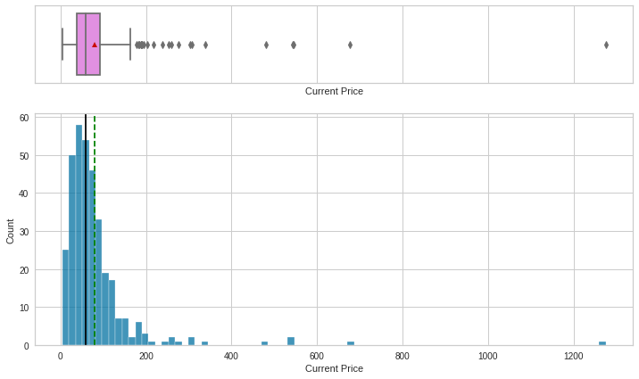

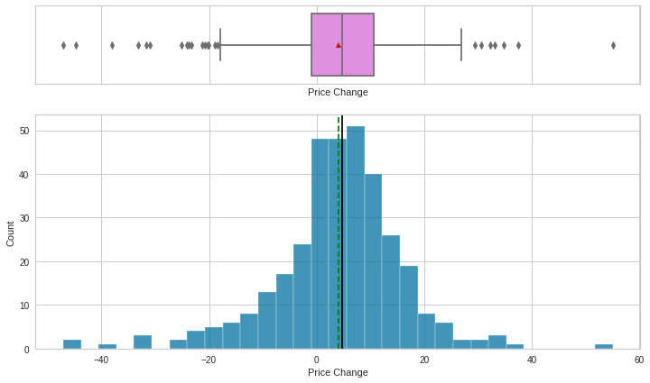

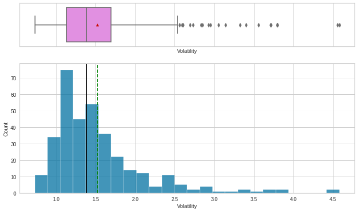

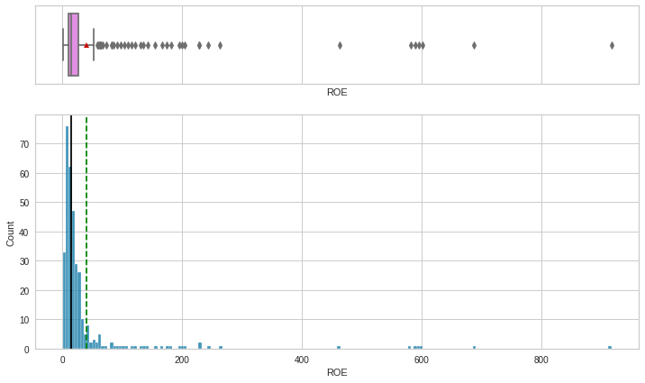

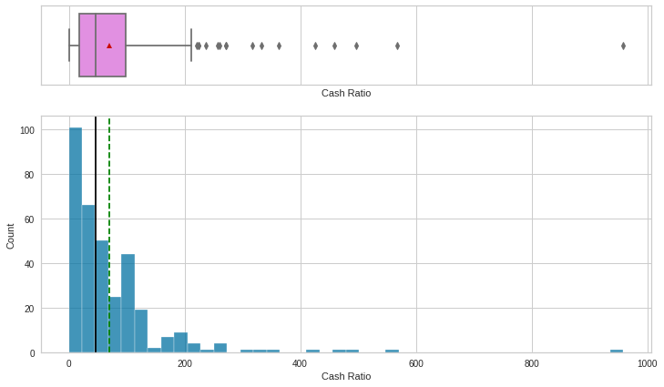

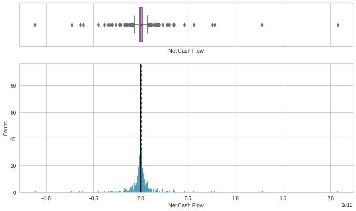

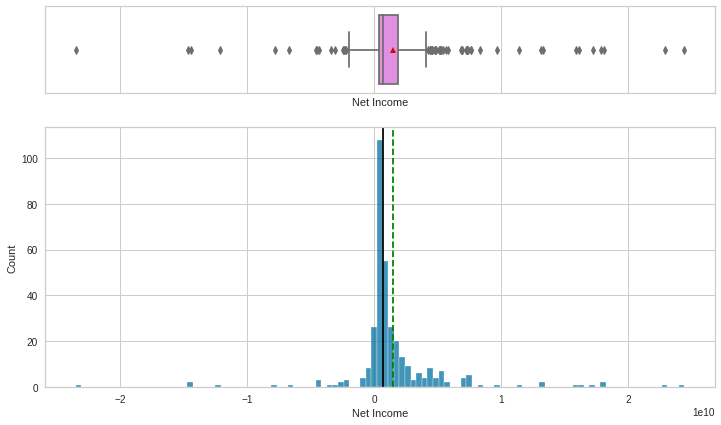

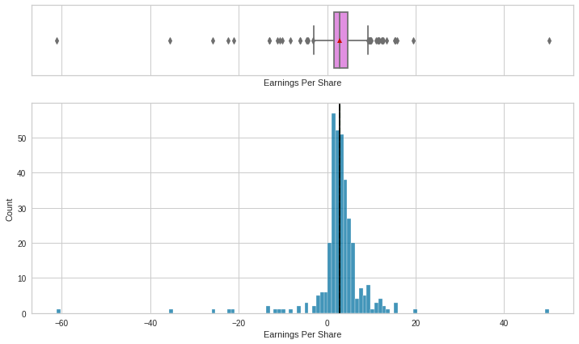

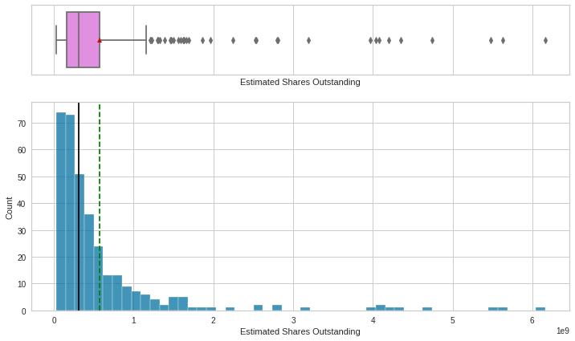

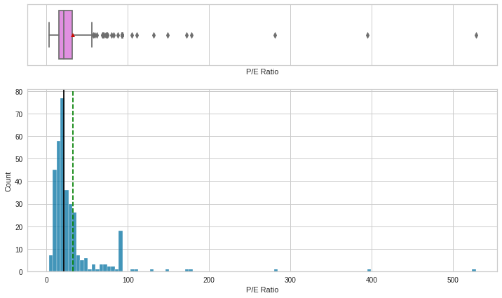

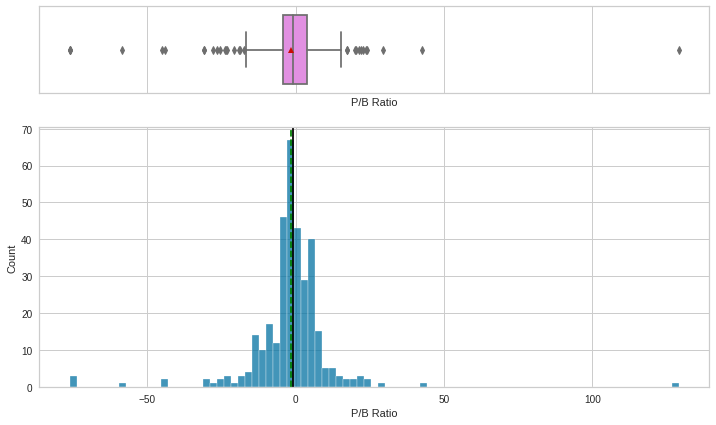

```python
for i in df_numeric.columns:
  histogram_boxplot(df_numeric, i, figsize=(12, 7), kde=False, bins=None)
```

There are actually a few variables that look fairly close to a normal distribution, including net cash flow, P/B ratio, EPS and Price Change. The rest have significant right skew as we could see in the initial data check, with a significant number of outliers on the high side.

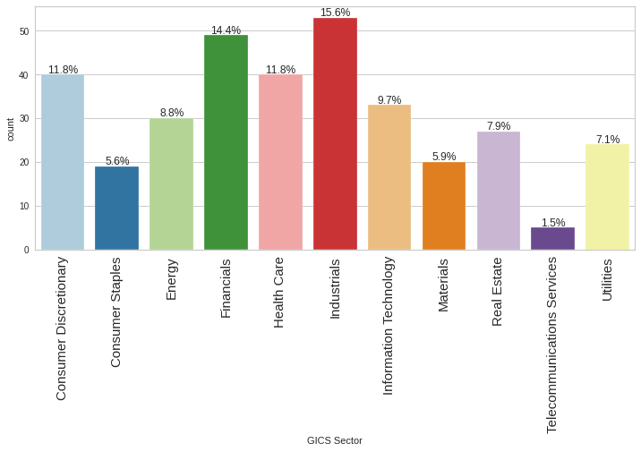

```python
labeled_barplot(df, 'GICS Sector', perc=True)
```

The stocks in this data set are fairly evenly distributed across the 11 industry sectors, with 10 of the sectors having between 5.6% and 15.6% of the entries. Only Telecommunications Services stands out significantly, representing just 1.5% of the stocks

[figure not shown]

```python
labeled_barplot(df, 'GICS Sub Industry', perc=True)
```

As opposed to industry sector, the sub industry variable is much more widely varied with 104 unique sub industries compared to the 11 main sectors. Only a few sub sectors represent more than 1% of the data, with Oil & Gas Exploration, REITS, and Industrial Conglomerates being the only sub sectors with more than 4% of the stocks.

## **Questions**:

1. What does the distribution of stock prices look like?
2. The stocks of which economic sector have seen the maximum price increase on average?
3. How are the different variables correlated with each other?
4. Cash ratio provides a measure of a company's ability to cover its short-term obligations using only cash and cash equivalents. How does the average cash ratio vary across economic sectors?
5. P/E ratios can help determine the relative value of a company's shares as they signify the amount of money an investor is willing to invest in a single share of a company per dollar of its earnings. How does the P/E ratio vary, on average, across economic sectors?

### What does the distribution of stock prices look like?

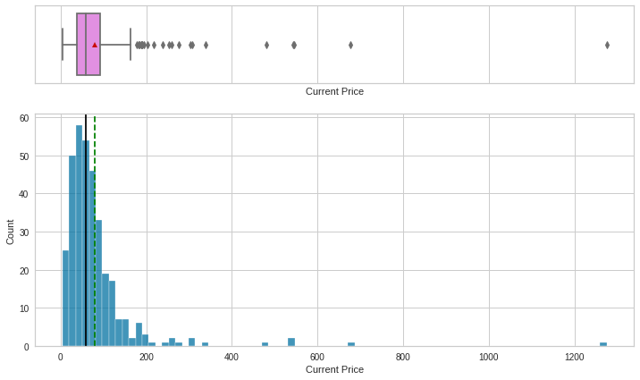

```python
histogram_boxplot(df, 'Current Price')
```

Current Price has a median near 60 and a mean near 80, with the right skew driven by a significant number of outliers above the upper whisker (which is around 175). The outliers range from nearly 200 all the way up to over 1200.

### The stocks of which economic sector have seen the maximum price increase on average?

```python
df.groupby('GICS Sector')['Price Change'].mean().sort_values(ascending = False)
```

```
GICS Sector
Health Care                     9.585652
Consumer Staples                8.684750
Information Technology          7.217476
Telecommunications Services     6.956980
Real Estate                     6.205548
Consumer Discretionary          5.846093
Materials                       5.589738
Financials                      3.865406
Industrials                     2.833127
Utilities                       0.803657
Energy                        -10.228289
Name: Price Change, dtype: float64
```

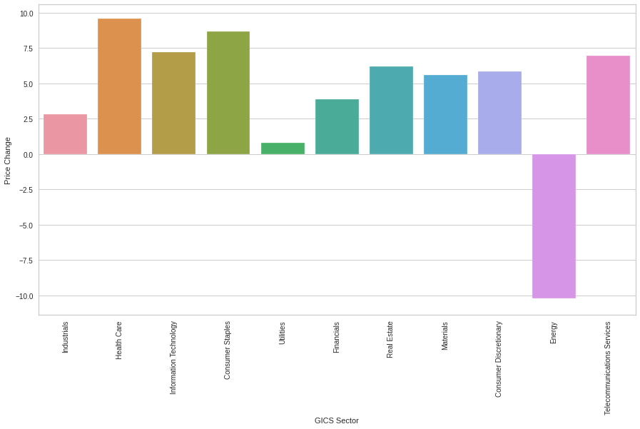

```python
plt.figure(figsize=(15,8))
sns.barplot(data=df, x='GICS Sector', y='Price Change', ci=False)
plt.xticks(rotation=90)
plt.show()
```

### How are the different variables correlated with each other?

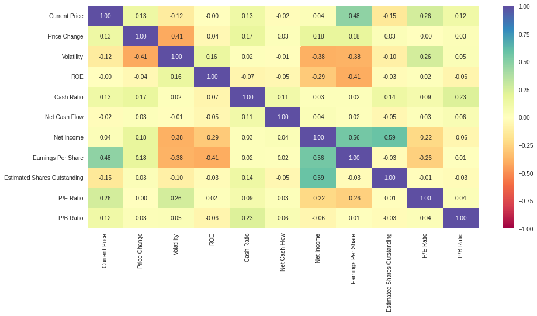

```python
plt.figure(figsize=(15, 7))
sns.heatmap(
    df.corr(), annot=True, vmin=-1, vmax=1, fmt=".2f", cmap="Spectral"
)
plt.show()
```

There are a handful of relatively strong correlations, notably EPS and Current Price (.48) and Net Income with both EPS and Shares Outstanding (.56 and .59). One very interesting correlation is that Volatility and Price Change have one off the most negative correlations at -.41, which may suggest that either highly volatile stocks end up averaging out to small price changes over time, or that stocks with lower prices are more volatile, so even though they have large variances, the overall price change isn't as significant. Current Price and Volatility do have a negative correlation, so there is likely some truth behind that.

### P/E ratios can help determine the relative value of a company's shares as they signify the amount of money an investor is willing to invest in a single share of a company per dollar of its earnings. How does the P/E ratio vary, on average, across economic sectors?

```python
df.groupby('GICS Sector')['P/E Ratio'].describe()
```

| GICS Sector | count | mean | std | min | 25% | 50% | 75% | max |
| --- | --- | --- | --- | --- | --- | --- | --- | --- |
| Consumer Discretionary | 40.0 | 35.211613 | 80.902902 | 5.566284 | 15.459391 | 20.819876 | 25.887634 | 528.039074 |
| Consumer Staples | 19.0 | 25.521195 | 10.291193 | 9.986637 | 21.391092 | 24.070121 | 26.176366 | 48.412370 |
| Energy | 30.0 | 72.897709 | 42.144306 | 8.429600 | 28.407929 | 93.089287 | 93.089287 | 171.962965 |
| Financials | 49.0 | 16.023151 | 7.281892 | 4.304511 | 10.914049 | 14.276451 | 18.703854 | 38.721154 |
| Health Care | 40.0 | 41.135272 | 46.756416 | 8.180275 | 19.165522 | 27.967442 | 35.700025 | 280.514706 |
| Industrials | 53.0 | 18.259380 | 7.587633 | 2.935451 | 13.048485 | 17.334711 | 20.556076 | 41.199999 |
| Information Technology | 33.0 | 43.782546 | 70.242260 | 10.209198 | 18.249407 | 25.309524 | 31.040405 | 394.413783 |
| Materials | 20.0 | 24.585352 | 12.349729 | 9.033264 | 16.001852 | 22.811951 | 32.226881 | 57.210844 |
| Real Estate | 27.0 | 43.065585 | 22.799372 | 13.164179 | 28.294875 | 33.685393 | 48.266787 | 110.764709 |
| Telecommunications Services | 5.0 | 12.222578 | 4.210623 | 5.598352 | 10.552512 | 14.518987 | 14.518987 | 15.924051 |
| Utilities | 24.0 | 18.719412 | 5.143485 | 9.293155 | 16.909186 | 18.216489 | 19.510019 | 33.792080 |

P/E Ratio looks to have very different distributions within different sectors, with certain sectors like Energy, Real Estate and IT having higher P/E ratios on average (as well as larger variances), while other sectors like Financials, Industrials, Utilities and Telecoms having much lower P/E ratio averages and variances.

One thing to note here: there looks to be some strange behavior on P/E ratios specifically within the Energy sector, where the median and 3rd quartile are exactly the same. Given that there are 30 Energy companies in this data set, that means that 8 or more companies have the exact same P/E ratio to the 6th decimal, which seems extremely unlikely. I want to explore this a bit further before I move on.

```python
data = df.copy()
```

```python
pe_rounded = data['P/E Ratio'].round(1)
```

```python
pe_calc = data['Current Price']/data['Earnings Per Share']
```

```python
data['pe_rounded'] = pe_rounded
```

```python
data['pe_calc'] = pe_calc.round(1)
```

```python
data.head()
```

|  | Ticker Symbol | Security | GICS Sector | GICS Sub Industry | Current Price | Price Change | Volatility | ROE | Cash Ratio | Net Cash Flow | Net Income | Earnings Per Share | Estimated Shares Outstanding | P/E Ratio | P/B Ratio | pe_rounded | pe_calc |
| --- | --- | --- | --- | --- | --- | --- | --- | --- | --- | --- | --- | --- | --- | --- | --- | --- | --- |
| 0 | AAL | American Airlines Group | Industrials | Airlines | 42.349998 | 9.999995 | 1.687151 | 135 | 51 | -604000000 | 7610000000 | 11.39 | 6.681299e+08 | 3.718174 | -8.784219 | 3.7 | 3.7 |
| 1 | ABBV | AbbVie | Health Care | Pharmaceuticals | 59.240002 | 8.339433 | 2.197887 | 130 | 77 | 51000000 | 5144000000 | 3.15 | 1.633016e+09 | 18.806350 | -8.750068 | 18.8 | 18.8 |
| 2 | ABT | Abbott Laboratories | Health Care | Health Care Equipment | 44.910000 | 11.301121 | 1.273646 | 21 | 67 | 938000000 | 4423000000 | 2.94 | 1.504422e+09 | 15.275510 | -0.394171 | 15.3 | 15.3 |
| 3 | ADBE | Adobe Systems Inc | Information Technology | Application Software | 93.940002 | 13.977195 | 1.357679 | 9 | 180 | -240840000 | 629551000 | 1.26 | 4.996437e+08 | 74.555557 | 4.199651 | 74.6 | 74.6 |
| 4 | ADI | Analog Devices, Inc. | Information Technology | Semiconductors | 55.320000 | -1.827858 | 1.701169 | 14 | 272 | 315120000 | 696878000 | 0.31 | 2.247994e+09 | 178.451613 | 1.059810 | 178.5 | 178.5 |

```python
data[abs(data['pe_rounded'] - data['pe_calc']) > 1]
```

|  | Ticker Symbol | Security | GICS Sector | GICS Sub Industry | Current Price | Price Change | Volatility | ROE | Cash Ratio | Net Cash Flow | Net Income | Earnings Per Share | Estimated Shares Outstanding | P/E Ratio | P/B Ratio | pe_rounded | pe_calc |
| --- | --- | --- | --- | --- | --- | --- | --- | --- | --- | --- | --- | --- | --- | --- | --- | --- | --- |
| 30 | APA | Apache Corporation | Energy | Oil & Gas Exploration & Production | 44.470001 | 11.397804 | 2.405408 | 917 | 80 | 698000000 | -23528000000 | -61.200 | 3.844444e+08 | 93.089287 | 4.970809 | 93.1 | -0.7 |
| 31 | APC | Anadarko Petroleum Corp | Energy | Oil & Gas Exploration & Production | 48.580002 | -20.802083 | 2.435165 | 52 | 22 | -6430000000 | -6692000000 | -13.180 | 5.077390e+08 | 93.089287 | -12.860938 | 93.1 | -3.7 |
| 33 | ARNC | Arconic Inc | Industrials | Aerospace & Defense | 7.398807 | 1.647784 | 2.592065 | 3 | 37 | 42000000 | -322000000 | -0.310 | 1.038710e+09 | 18.687607 | 2.639814 | 18.7 | -23.9 |
| 36 | AVGO | Broadcom | Information Technology | Semiconductors | 145.149994 | 17.902683 | 1.847180 | 29 | 163 | 218000000 | 1364000000 | 2.860 | 1.044056e+09 | 18.249407 | 3.954975 | 18.2 | 50.8 |
| 38 | AXP | American Express Co | Financials | Consumer Finance | 69.550003 | -6.216290 | 0.900066 | 25 | 99 | 474000000 | 5163000000 | 3.900 | 5.066604e+08 | 10.263506 | -0.609074 | 10.3 | 17.8 |
| 40 | BAC | Bank of America Corp | Financials | Banks | 16.830000 | 8.440722 | 1.418688 | 6 | 99 | 20764000000 | 15888000000 | 4.180 | 8.450695e+08 | 13.004785 | -0.938007 | 13.0 | 4.0 |
| 44 | BHI | Baker Hughes Inc | Energy | Oil & Gas Equipment & Services | 46.150002 | -12.312367 | 2.559553 | 12 | 84 | 584000000 | -1967000000 | -4.490 | 4.380846e+08 | 93.089287 | 13.490544 | 93.1 | -10.3 |
| 49 | BSX | Boston Scientific | Health Care | Health Care Equipment | 18.440001 | 11.757582 | 1.491764 | 4 | 13 | -268000000 | -239000000 | -0.180 | 1.327778e+09 | 31.468962 | -3.880921 | 31.5 | -102.4 |
| 62 | CHK | Chesapeake Energy | Energy | Integrated Oil & Gas | 4.500000 | -38.101788 | 4.559815 | 687 | 22 | -3283000000 | -14685000000 | -22.430 | 6.547035e+08 | 28.407929 | -1.840528 | 28.4 | -0.2 |
| 64 | CHTR | Charter Communications | Consumer Discretionary | Cable & Satellite | 183.100006 | 3.598507 | 1.697942 | 589 | 0 | 2000000 | -271000000 | -2.430 | 1.115226e+08 | 20.819876 | -76.119077 | 20.8 | -75.3 |
| 74 | CNP | CenterPoint Energy | Utilities | MultiUtilities | 18.360001 | 1.436470 | 1.389867 | 20 | 43 | -34000000 | -692000000 | -1.610 | 4.298137e+08 | 17.313076 | 0.516503 | 17.3 | -11.4 |
| 76 | COG | Cabot Oil & Gas | Energy | Oil & Gas Exploration & Production | 17.690001 | -20.099360 | 3.055818 | 6 | 0 | -20440000 | -113891000 | -0.280 | 4.067536e+08 | 93.089287 | -0.223147 | 93.1 | -63.2 |
| 77 | COO | The Cooper Companies | Health Care | Health Care Supplies | 134.199997 | -9.672215 | 1.555057 | 8 | 3 | -8796000 | 203523000 | 1.790 | 1.403352e+08 | 33.994412 | 0.855096 | 34.0 | 75.0 |
| 88 | DE | Deere & Co. | Industrials | Construction & Farm Machinery & Heavy Trucks | 76.269997 | 3.952561 | 1.551946 | 29 | 22 | 375200000 | 1940000000 | 4.030 | 5.322359e+08 | 14.842233 | 6.277287 | 14.8 | 18.9 |
| 93 | DISCA | Discovery Communications-A | Consumer Discretionary | Cable & Satellite | 26.680000 | 2.026769 | 1.689235 | 19 | 25 | 23000000 | 1034000000 | -2.430 | 1.115226e+08 | 20.819876 | -76.119077 | 20.8 | -11.0 |
| 94 | DISCK | Discovery Communications-C | Consumer Discretionary | Cable & Satellite | 25.219999 | 3.572891 | 1.812144 | 19 | 25 | 23000000 | 1034000000 | -2.430 | 1.115226e+08 | 20.819876 | -76.119077 | 20.8 | -10.4 |
| 102 | DVN | Devon Energy Corp. | Energy | Oil & Gas Exploration & Production | 32.000000 | -15.478079 | 2.923698 | 205 | 70 | 830000000 | -14454000000 | -35.550 | 4.065823e+08 | 93.089287 | 1.785616 | 93.1 | -0.9 |
| 109 | EOG | EOG Resources | Energy | Oil & Gas Exploration & Production | 70.790001 | -4.078593 | 1.941104 | 35 | 39 | -1368707000 | -4524515000 | -8.290 | 5.457799e+08 | 93.089287 | 1.416243 | 93.1 | -8.5 |
| 117 | ETR | Entergy Corp. | Utilities | Electric Utilities | 68.360001 | 4.910983 | 1.217401 | 2 | 44 | -71065000 | -156734000 | -0.990 | 1.583172e+08 | 18.456543 | 6.174024 | 18.5 | -69.1 |
| 119 | EXC | Exelon Corp. | Utilities | MultiUtilities | 27.770000 | -6.403775 | 1.351595 | 9 | 74 | 4624000000 | 2269000000 | 2.685 | 2.998871e+08 | 17.313076 | -1.715880 | 17.3 | 10.3 |
| 127 | FCX | Freeport-McMoran Cp & Gld | Materials | Copper | 6.770000 | -31.685167 | 3.796410 | 155 | 5 | -240000000 | -12156000000 | -11.310 | 1.074801e+09 | 22.811951 | 2.935427 | 22.8 | -0.6 |
| 137 | FTR | Frontier Communications | Telecommunications Services | Integrated Telecommunications Services | 4.670000 | -2.301255 | 2.026818 | 3 | 496 | 254000000 | -196000000 | -0.290 | 6.758621e+08 | 14.518987 | 10.497704 | 14.5 | -16.1 |
| 139 | GGP | General Growth Properties Inc. | Real Estate | Retail REITs | 27.209999 | 4.212937 | 1.390342 | 17 | 47 | -15576000 | 1374561000 | 3.040 | 1.582994e+08 | 47.366973 | -3.973395 | 47.4 | 9.0 |
| 147 | HAL | Halliburton Co. | Energy | Oil & Gas Equipment & Services | 34.040001 | -5.101751 | 1.966062 | 4 | 189 | 7786000000 | -671000000 | -0.790 | 8.493671e+08 | 93.089287 | 17.345857 | 93.1 | -43.1 |
| 152 | HCP | HCP Inc. | Real Estate | REITs | 34.826959 | 2.218658 | 1.282286 | 6 | 47 | 162690000 | -559235000 | -1.210 | 4.621777e+08 | 33.651715 | -1.269332 | 33.7 | -28.8 |
| 153 | HES | Hess Corporation | Energy | Integrated Oil & Gas | 48.480000 | -4.585713 | 2.398580 | 16 | 103 | 272000000 | -3056000000 | -10.780 | 2.834879e+08 | 28.407929 | 6.264817 | 28.4 | -4.5 |
| 157 | HPE | Hewlett Packard Enterprise | Information Technology | Technology Hardware, Storage & Peripherals | 15.200000 | -17.837838 | 3.400491 | 7 | 45 | 7523000000 | 2461000000 | 1.800 | 5.139877e+08 | 25.309524 | 3.954975 | 25.3 | 8.4 |
| 158 | HPQ | HP Inc. | Information Technology | Computer Hardware | 11.840000 | 2.161759 | 2.373359 | 16 | 18 | 2300000000 | 4554000000 | 1.800 | 5.139877e+08 | 25.309524 | 3.954975 | 25.3 | 6.6 |
| 159 | HRL | Hormel Foods Corp. | Consumer Staples | Packaged Foods & Meats | 39.540001 | 24.496225 | 1.078455 | 17 | 29 | 13065000 | 686088000 | 3.280 | 1.992378e+08 | 24.070121 | -1.980483 | 24.1 | 12.1 |
| 162 | HSY | The Hershey Company | Consumer Staples | Packaged Foods & Meats | 89.269997 | -3.261814 | 1.188383 | 51 | 16 | -28325000 | 512951000 | 3.280 | 1.992378e+08 | 24.070121 | -1.980483 | 24.1 | 27.2 |
| 185 | LH | Laboratory Corp. of America Holding | Health Care | Health Care Facilities | 123.639999 | 14.174899 | 1.603130 | 9 | 42 | 136400000 | 436900000 | 5.030 | 1.782465e+08 | 15.900937 | -1.294844 | 15.9 | 24.6 |
| 186 | LKQ | LKQ Corporation | Consumer Discretionary | Distributors | 29.629999 | 4.441304 | 1.427237 | 14 | 12 | -27208000 | 423223000 | 3.030 | 2.135983e+08 | 20.819876 | -0.857290 | 20.8 | 9.8 |
| 187 | LLL | L-3 Communications Holdings | Industrials | Industrial Conglomerates | 119.510002 | 14.539013 | 1.513434 | 6 | 7 | -235000000 | -240000000 | -2.970 | 8.080808e+07 | 17.334711 | 14.280750 | 17.3 | -40.2 |
| 211 | MNST | Monster Beverage | Consumer Staples | Soft Drinks | 49.653332 | 10.800357 | 1.585944 | 11 | 568 | 1805094000 | 546733000 | 3.710 | 1.469542e+09 | 25.420118 | -5.190734 | 25.4 | 13.4 |
| 216 | MRO | Marathon Oil Corp. | Energy | Oil & Gas Exploration & Production | 12.590000 | -20.265991 | 3.325386 | 12 | 71 | -1177000000 | -2204000000 | -3.260 | 6.760736e+08 | 93.089287 | 1.273530 | 93.1 | -3.9 |
| 219 | MUR | Murphy Oil | Energy | Integrated Oil & Gas | 22.450001 | -8.591197 | 2.851180 | 43 | 27 | -910125000 | -2270833000 | -13.030 | 1.742773e+08 | 28.407929 | -1.298006 | 28.4 | -1.7 |
| 222 | NBL | Noble Energy Inc | Energy | Oil & Gas Exploration & Production | 32.930000 | 7.298791 | 2.509437 | 24 | 57 | -155000000 | -2441000000 | -6.070 | 4.021417e+08 | 93.089287 | 1.171229 | 93.1 | -5.4 |
| 227 | NFX | Newfield Exploration Co | Energy | Oil & Gas Exploration & Production | 32.560001 | -3.296695 | 2.421529 | 244 | 1 | -9000000 | -3362000000 | -21.180 | 1.587347e+08 | 93.089287 | -0.138596 | 93.1 | -1.5 |
| 229 | NOV | National Oilwell Varco Inc. | Energy | Oil & Gas Equipment & Services | 33.490002 | -12.558739 | 1.952020 | 5 | 49 | -1456000000 | -769000000 | -1.990 | 3.864322e+08 | 93.089287 | 9.582536 | 93.1 | -16.8 |
| 238 | OXY | Occidental Petroleum | Energy | Oil & Gas Exploration & Production | 67.610001 | 0.865287 | 1.589520 | 32 | 64 | -588000000 | -7829000000 | -10.230 | 7.652981e+08 | 93.089287 | 3.345102 | 93.1 | -6.6 |
| 253 | PNR | Pentair Ltd. | Industrials | Industrial Machinery | 49.529999 | -3.034462 | 1.875910 | 2 | 8 | 15900000 | -76400000 | -0.420 | 1.819048e+08 | 14.579221 | -6.574869 | 14.6 | -117.9 |
| 267 | RRC | Range Resources Corp. | Energy | Oil & Gas Exploration & Production | 24.610001 | -25.106512 | 3.712995 | 26 | 0 | 23000 | -713685000 | -4.290 | 1.663601e+08 | 93.089287 | 0.525090 | 93.1 | -5.7 |
| 284 | SWN | Southwestern Energy | Energy | Oil & Gas Exploration & Production | 7.110000 | -44.798137 | 4.580042 | 200 | 2 | -38000000 | -4556000000 | -6.070 | 4.021417e+08 | 93.089287 | 1.273530 | 93.1 | -1.2 |
| 289 | TDC | Teradata Corp. | Information Technology | Application Software | 26.420000 | -8.833678 | 2.730659 | 25 | 88 | 5000000 | -214000000 | -1.530 | 1.398693e+08 | 74.555557 | 4.068084 | 74.6 | -17.3 |
| 296 | TSN | Tyson Foods | Consumer Staples | Packaged Foods & Meats | 53.330002 | 23.249369 | 1.586719 | 13 | 19 | 250000000 | 1220000000 | 3.280 | 1.992378e+08 | 24.070121 | -1.980483 | 24.1 | 16.3 |
| 300 | UAA | Under Armour | Consumer Discretionary | Apparel, Accessories & Luxury Goods | 80.610001 | -16.948277 | 1.758824 | 14 | 27 | -463323000 | 232573000 | 3.030 | 2.135983e+08 | 20.819876 | -0.857290 | 20.8 | 26.6 |
| 315 | VRTX | Vertex Pharmaceuticals Inc | Health Care | Biotechnology | 125.830002 | 21.928300 | 2.456535 | 59 | 221 | 89509000 | -556334000 | -2.310 | 2.408372e+08 | 39.602928 | 2.559671 | 39.6 | -54.5 |
| 323 | WMB | Williams Cos. | Energy | Oil & Gas Exploration & Production | 25.700001 | -30.988186 | 3.719560 | 9 | 4 | -140000000 | -571000000 | -0.760 | 7.513158e+08 | 93.089287 | -14.561121 | 93.1 | -33.8 |
| 328 | XEC | Cimarex Energy | Energy | Oil & Gas Exploration & Production | 89.379997 | -14.403372 | 2.397940 | 86 | 190 | 373520000 | -2408948000 | -25.920 | 9.293781e+07 | 93.089287 | 7.186128 | 93.1 | -3.4 |
| 335 | YHOO | Yahoo Inc. | Information Technology | Internet Software & Services | 33.259998 | 14.887727 | 1.845149 | 15 | 459 | -1032187000 | -4359082000 | -4.640 | 9.394573e+08 | 28.976191 | 6.261775 | 29.0 | -7.2 |

There are 50 companies in the data set where the value in the P/E ratio column is different than the literal calculation of current price divided by EPS. The majority of these are on companies with a negative EPS, meaning the company isn't currently making a loss instead of a profit. Because I don't have advanced knowledge of the stock market and company financials, I'm planning to leave the P/E ratio values as they are, though if I were actually working for Trade&Ahead I would make sure to clarify with team members whether this data is inaccurate and use that additional knowledge to further clean this data set.

### Cash ratio provides a measure of a company's ability to cover its short-term obligations using only cash and cash equivalents. How does the average cash ratio vary across economic sectors?

```python
df.groupby('GICS Sector')['Cash Ratio'].mean().sort_values(ascending = False)
```

```
GICS Sector
Information Technology         149.818182
Telecommunications Services    117.000000
Health Care                    103.775000
Financials                      98.591837
Consumer Staples                70.947368
Energy                          51.133333
Real Estate                     50.111111
Consumer Discretionary          49.575000
Materials                       41.700000
Industrials                     36.188679
Utilities                       13.625000
Name: Cash Ratio, dtype: float64
```

The average cash ratio by economic sector varies widely, from 14 for Utilities companies to 150 for IT companies. It seems that in general the companies with lower cash ratios likely have more of their funds tied up in physical assets, like with utilities, industrials, materials and real estate companies.

## Data Preprocessing

- Duplicate value check
- Missing value treatment
- Outlier check
- Feature engineering (if needed)
- Any other preprocessing steps (if needed)

We previously checked for duplicated and missing values and found nothing that needed to be cleaned up. For outliers, there are a significant number of outliers in many of the variables. However, they all appear to be legitimate data points so we need to keep them in the data set. Additionally, I'm choosing to not cap them at the whiskers for three reasons: First, the majority of outliers in most variables are skewed to the high side which represents a handful of typically very high value companies. Second, the variances in many of these variables are very different between sectors, so capping outliers could have a large impact on certain sectors and lead to them being more similar to other sectors than they truly are. Third, capping these outliers may have a significant impact on the clusters we create and could lead to misleading clusters and averages that don't truly represent the data.

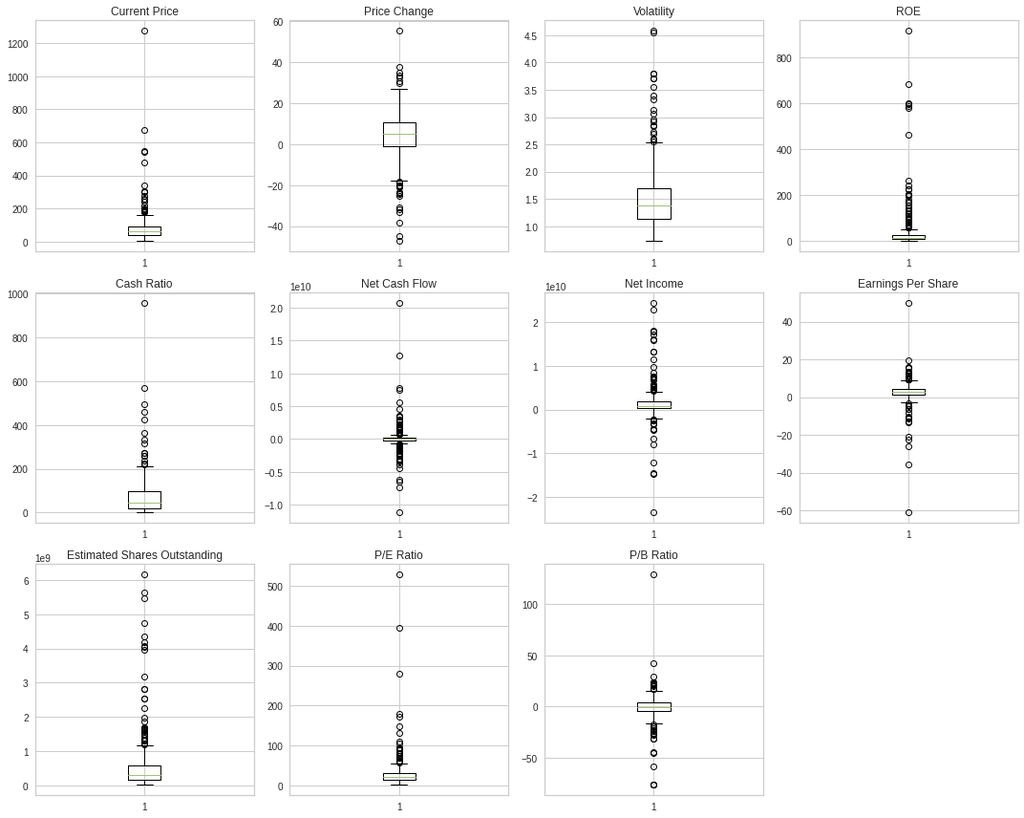

```python
plt.figure(figsize=(15, 12))

numeric_columns = df.select_dtypes(include=np.number).columns.tolist()

for i, variable in enumerate(numeric_columns):
    plt.subplot(3, 4, i + 1)
    plt.boxplot(df[variable], whis=1.5)
    plt.tight_layout()
    plt.title(variable)

plt.show()
```

## Scaling Data

```python
# scaling the data before clustering
sc = StandardScaler()

subset = df.drop(["Ticker Symbol", "Security", "GICS Sector", "GICS Sub Industry"], axis=1)

subset_scaled = sc.fit_transform(subset)
```

```python
subset_scaled_df = pd.DataFrame(subset_scaled, columns=subset.columns)
```

```python
subset_scaled_df.describe().T
```

|  | count | mean | std | min | 25% | 50% | 75% | max |
| --- | --- | --- | --- | --- | --- | --- | --- | --- |
| Current Price | 340.0 | 1.453086e-17 | 1.001474 | -0.779918 | -0.432101 | -0.216088 | 0.122741 | 12.195670 |
| Price Change | 340.0 | -1.502066e-17 | 1.001474 | -4.271357 | -0.418535 | 0.061834 | 0.551963 | 4.251806 |
| Volatility | 340.0 | -6.587868e-17 | 1.001474 | -1.341642 | -0.661838 | -0.237564 | 0.286960 | 5.168258 |
| ROE | 340.0 | 2.873518e-17 | 1.001474 | -0.400362 | -0.309599 | -0.255142 | -0.130667 | 9.101176 |
| Cash Ratio | 340.0 | -8.196058e-17 | 1.001474 | -0.775555 | -0.576194 | -0.255000 | 0.320933 | 9.834905 |
| Net Cash Flow | 340.0 | -7.224613e-18 | 1.001474 | -5.795489 | -0.128348 | -0.027497 | 0.058798 | 10.655237 |
| Net Income | 340.0 | 6.040919e-18 | 1.001474 | -6.359977 | -0.290285 | -0.200045 | 0.102842 | 5.832629 |
| Earnings Per Share | 340.0 | 4.555180e-17 | 1.001474 | -9.725729 | -0.185337 | 0.017990 | 0.280224 | 7.192572 |
| Estimated Shares Outstanding | 340.0 | -1.244511e-16 | 1.001474 | -0.650430 | -0.495119 | -0.316542 | -0.004630 | 6.609320 |
| P/E Ratio | 340.0 | 1.665335e-17 | 1.001474 | -0.670162 | -0.396715 | -0.266300 | -0.019145 | 11.187619 |
| P/B Ratio | 340.0 | 4.930696e-17 | 1.001474 | -5.334786 | -0.188853 | 0.046685 | 0.404071 | 9.377562 |

## K-means Clustering

```python
kmeans_df = subset_scaled_df.copy()
```

```
Number of Clusters: 1 	Average Distortion: 2.5425069919221697
Number of Clusters: 2 	Average Distortion: 2.382318498894466
Number of Clusters: 3 	Average Distortion: 2.269236715539074
Number of Clusters: 4 	Average Distortion: 2.1745559827866363
Number of Clusters: 5 	Average Distortion: 2.128799332840716
Number of Clusters: 6 	Average Distortion: 2.0804000992262885
Number of Clusters: 7 	Average Distortion: 2.0289794220177395
Number of Clusters: 8 	Average Distortion: 1.964144163389972
Number of Clusters: 9 	Average Distortion: 1.9221492045198068
Number of Clusters: 10 	Average Distortion: 1.8513913649973124
Number of Clusters: 11 	Average Distortion: 1.8024134734578485
Number of Clusters: 12 	Average Distortion: 1.7900931879652673
Number of Clusters: 13 	Average Distortion: 1.7417609203336912
Number of Clusters: 14 	Average Distortion: 1.6735598572597035
```

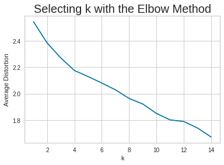

```python
clusters = range(1, 15)
meanDistortions = []

for k in clusters:
    model = KMeans(n_clusters=k, random_state=1)
    model.fit(subset_scaled_df)
    prediction = model.predict(kmeans_df)
    distortion = (
        sum(np.min(cdist(kmeans_df, model.cluster_centers_, "euclidean"), axis=1))
        / kmeans_df.shape[0]
    )

    meanDistortions.append(distortion)

    print("Number of Clusters:", k, "\tAverage Distortion:", distortion)

plt.plot(clusters, meanDistortions, "bx-")
plt.xlabel("k")
plt.ylabel("Average Distortion")
plt.title("Selecting k with the Elbow Method", fontsize=20)
plt.show()
```

There is not a really clear spot to use from the elbow method, although it looks like 4, 8 and 11 could be good possibilities.

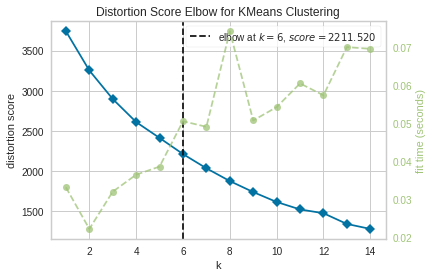

```python
model = KMeans(random_state=1)
visualizer = KElbowVisualizer(model, k=(1, 15), timings=True)
visualizer.fit(kmeans_df)  # fit the data to the visualizer
visualizer.show()  # finalize and render figure
```

##### Silhouette Scores

```
For n_clusters = 2, the silhouette score is 0.43969639509980457)
For n_clusters = 3, the silhouette score is 0.4644405674779404)
For n_clusters = 4, the silhouette score is 0.4577225970476733)
For n_clusters = 5, the silhouette score is 0.43228336443659804)
For n_clusters = 6, the silhouette score is 0.4005422737213617)
For n_clusters = 7, the silhouette score is 0.3976335364987305)
For n_clusters = 8, the silhouette score is 0.40278401969450467)
For n_clusters = 9, the silhouette score is 0.3778585981433699)
For n_clusters = 10, the silhouette score is 0.13458938329968687)
For n_clusters = 11, the silhouette score is 0.1421832155528444)
For n_clusters = 12, the silhouette score is 0.2044669621527429)
For n_clusters = 13, the silhouette score is 0.23424874810104204)
For n_clusters = 14, the silhouette score is 0.12102526472829901)
```

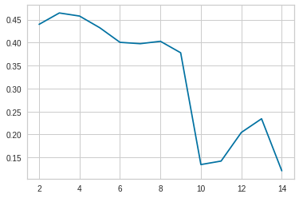

```python
sil_score = []
cluster_list = range(2, 15)
for n_clusters in cluster_list:
    clusterer = KMeans(n_clusters=n_clusters, random_state=1)
    preds = clusterer.fit_predict((subset_scaled_df))
    score = silhouette_score(kmeans_df, preds)
    sil_score.append(score)
    print("For n_clusters = {}, the silhouette score is {})".format(n_clusters, score))

plt.plot(cluster_list, sil_score)
plt.show()
```

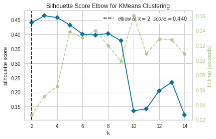

```python
model = KMeans(random_state=1)
visualizer = KElbowVisualizer(model, k=(2, 15), metric="silhouette", timings=True)
visualizer.fit(kmeans_df)  # fit the data to the visualizer
visualizer.show()  # finalize and render figure
```

Based on the silhouette score chart, I want to look at 3, 4, 8 and 13 clusters. 3 and 4 have the highest scores and 8 is the largest number of clusters before there's a significant drop off in silhouette score, while 13 has a high score compared to the other cluster numbers around it, so for a high number of clusters it looks to perform well.

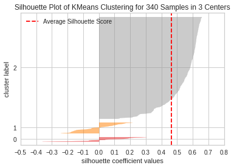

```python
# choose number of clusters based on silhouette scores
visualizer = SilhouetteVisualizer(KMeans(3, random_state=1))
visualizer.fit(kmeans_df)
visualizer.show()
```

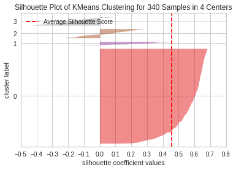

```python
visualizer = SilhouetteVisualizer(KMeans(4, random_state=1))
visualizer.fit(kmeans_df)
visualizer.show()
```

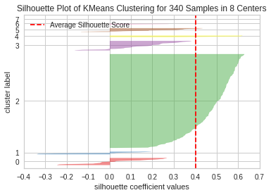

```python
visualizer = SilhouetteVisualizer(KMeans(8, random_state=1))
visualizer.fit(kmeans_df)
visualizer.show()
```

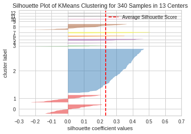

```python
visualizer = SilhouetteVisualizer(KMeans(13, random_state=1))
visualizer.fit(kmeans_df)
visualizer.show()
```

None of these silhouette plots give us an ideal number of clusters, as there's continually a trend of one cluster having the high majority of data points and therefore skewing the average silhouette score, and then many of the other clusters have below average silhouette scores. Of these choices, however, it appears that 13 is the best option as it has the most even distribution of data points and is closest to having all clusters not be below the average score.

```python
# final K-means model
kmeans = KMeans(n_clusters=13, random_state=1)  ## Complete the code to choose the number of clusters
kmeans.fit(kmeans_df)
```

```
KMeans(n_clusters=13, random_state=1)
```

```python
# creating a new copy and add kmeans labels to original and scaled dataframes
df1 = df.copy()
kmeans_df["KM_segments"] = kmeans.labels_
df1["KM_segments"] = kmeans.labels_
```

```python
# Grouping by cluster labels
kmeans_cluster_profile = df1.groupby("KM_segments").mean()
```

```python
kmeans_cluster_profile["count_in_each_segment"] = (
    df1.groupby("KM_segments")["Security"].count().values
)
```

```python
kmeans_cluster_profile.style.highlight_max(color="lightgreen", axis=0)
```

| KM_segments | Current Price | Price Change | Volatility | ROE | Cash Ratio | Net Cash Flow | Net Income | Earnings Per Share | Estimated Shares Outstanding | P/E Ratio | P/B Ratio | count_in_each_segment |
| --- | --- | --- | --- | --- | --- | --- | --- | --- | --- | --- | --- | --- |
| 0 | 87.750714 | 6.493815 | 1.263817 | 46.523810 | 68.142857 | 535321428.571429 | 5464911904.761905 | 6.613333 | 1109268300.866667 | 17.144309 | -2.236844 | 42 |
| 1 | 62.440873 | 16.496145 | 1.842172 | 28.727273 | 152.424242 | 15584454.545455 | 906482696.969697 | 1.901818 | 693964716.224242 | 38.656467 | 5.729196 | 33 |
| 2 | 71.338384 | 3.754053 | 1.351596 | 21.447761 | 45.179104 | -17599323.383085 | 903304940.298507 | 3.341468 | 299324257.335970 | 23.887399 | -2.398044 | 201 |
| 3 | 429.569995 | 3.761200 | 1.565483 | 18.000000 | 174.400000 | 362405800.000000 | 496954600.000000 | 9.900000 | 59200701.450000 | 55.569866 | 46.627828 | 5 |
| 4 | 24.485001 | -13.351992 | 3.482611 | 802.000000 | 51.000000 | -1292500000.000000 | -19106500000.000000 | -41.815000 | 519573983.250000 | 60.748608 | 1.565141 | 2 |
| 5 | 50.744999 | 5.512605 | 1.070356 | 24.875000 | 60.250000 | -3860125000.000000 | 15782875000.000000 | 3.632500 | 4640082627.625000 | 16.598649 | -7.787061 | 8 |
| 6 | 65.364667 | 10.707298 | 1.564626 | 12.000000 | 581.200000 | 336879000.000000 | 25940800.000000 | 1.158000 | 1193582906.920000 | 34.483791 | 9.400072 | 5 |
| 7 | 101.838570 | 0.089939 | 1.772285 | 15.142857 | 46.428571 | 52442714.285714 | 1134066428.571429 | 4.841429 | 155080956.911429 | 19.023144 | -51.728525 | 7 |
| 8 | 35.263847 | -16.175693 | 2.841300 | 49.769231 | 48.153846 | -135215038.461538 | -2525946153.846154 | -6.514231 | 482428533.751538 | 77.817252 | 1.618150 | 26 |
| 9 | 1274.949951 | 3.190527 | 1.268340 | 29.000000 | 184.000000 | -1671386000.000000 | 2551360000.000000 | 50.090000 | 50935516.070000 | 25.453183 | -1.052429 | 1 |
| 10 | 25.640000 | 11.237908 | 1.322355 | 12.500000 | 130.500000 | 16755500000.000000 | 13654000000.000000 | 3.295000 | 2791829362.100000 | 13.649696 | 1.508484 | 2 |
| 11 | 108.304002 | 10.737770 | 1.165694 | 566.200000 | 26.600000 | -278760000.000000 | 687180000.000000 | 1.548000 | 349607057.720000 | 34.898915 | -16.851358 | 5 |
| 12 | 327.006671 | 21.917380 | 2.029752 | 4.000000 | 106.000000 | 698240666.666667 | 287547000.000000 | 0.750000 | 366763235.300000 | 400.989188 | -5.322376 | 3 |

```python
for cl in df1["KM_segments"].unique():
    print("In cluster {}, the following companies are present:".format(cl))
    print(df1[df1["KM_segments"] == cl]["Security"].unique())
    print()
```

```
In cluster 0, the following companies are present:
['American Airlines Group' 'AbbVie' 'Abbott Laboratories'
 'American International Group, Inc.' 'American Express Co'
 'Boeing Company' 'BIOGEN IDEC Inc.' 'The Bank of New York Mellon Corp.'
 'Chubb Limited' 'Capital One Financial' 'CVS Health' 'Chevron Corp.'
 'Delta Air Lines' 'The Walt Disney Company' 'Ford Motor'
 'Gilead Sciences' 'General Motors' "Honeywell Int'l Inc."
 'Host Hotels & Resorts' 'International Business Machines'
 'Lockheed Martin Corp.' 'Level 3 Communications' 'LyondellBasell'
 'Mastercard Inc.' "McDonald's Corp." 'Mondelez International'
 'MetLife Inc.' '3M Company' 'Altria Group Inc' 'Merck & Co.'
 'PepsiCo Inc.' 'Philip Morris International' 'PNC Financial Services'
 'Prudential Financial' 'The Travelers Companies Inc.' 'Texas Instruments'
 'United Continental Holdings' 'United Health Group Inc.' 'Union Pacific'
 'United Parcel Service' 'United Technologies' 'Valero Energy']

In cluster 1, the following companies are present:
['Adobe Systems Inc' 'Analog Devices, Inc.' 'Applied Materials Inc'
 'Amgen Inc' 'Arconic Inc' 'Activision Blizzard' 'Broadcom'
 'Baxter International Inc.' 'Bristol-Myers Squibb' 'Celgene Corp.'
 'Centene Corporation' 'Du Pont (E.I.)' 'eBay Inc.' 'Edwards Lifesciences'
 'Fluor Corp.' 'First Solar Inc' 'Corning Inc.' 'Halliburton Co.'
 'Juniper Networks' 'Mattel Inc.' "Moody's Corp" 'Mead Johnson'
 'Mylan N.V.' 'Newmont Mining Corp. (Hldg. Co.)' 'Nucor Corp.' 'PayPal'
 'Charles Schwab Corporation' 'Skyworks Solutions' 'TripAdvisor'
 'Verisign Inc.' 'Vertex Pharmaceuticals Inc' 'Wynn Resorts Ltd' 'Zoetis']

In cluster 2, the following companies are present:
['Archer-Daniels-Midland Co' 'Ameren Corp' 'American Electric Power'
 'AFLAC Inc' 'Apartment Investment & Mgmt' 'Assurant Inc'
 'Arthur J. Gallagher & Co.' 'Akamai Technologies Inc' 'Albemarle Corp'
 'Alaska Air Group Inc' 'Allstate Corp' 'AMETEK Inc'
 'Ameriprise Financial' 'American Tower Corp A' 'AutoNation Inc' 'Aon plc'
 'Amphenol Corp' 'AvalonBay Communities, Inc.'
 'American Water Works Company Inc' 'BB&T Corporation' 'Bard (C.R.) Inc.'
 'Ball Corp' 'Boston Scientific' 'BorgWarner' 'Boston Properties'
 'Caterpillar Inc.' 'CBRE Group' 'Crown Castle International Corp.'
 'Carnival Corp.' 'CF Industries Holdings Inc' 'Citizens Financial Group'
 'Church & Dwight' 'C. H. Robinson Worldwide' 'CIGNA Corp.'
 'Cincinnati Financial' 'Comerica Inc.' 'Cummins Inc.' 'CMS Energy'
```

[output cut: 80 more lines]

```
 'Williams Cos.' 'Cimarex Energy']

In cluster 10, the following companies are present:
['Bank of America Corp' 'Intel Corp.']

In cluster 5, the following companies are present:
['Citigroup Inc.' 'JPMorgan Chase & Co.' 'Coca Cola Company' 'Pfizer Inc.'
 'AT&T Inc' 'Verizon Communications' 'Wells Fargo' 'Exxon Mobil Corp.']

In cluster 6, the following companies are present:
['Facebook' 'Frontier Communications' 'Monster Beverage'
 'Waters Corporation' 'Yahoo Inc.']

In cluster 9, the following companies are present:
['Priceline.com Inc']
```

```python
df1.groupby(["KM_segments", "GICS Sector"])['Security'].count()
```

```
KM_segments  GICS Sector
0            Consumer Discretionary          4
             Consumer Staples                5
             Energy                          2
             Financials                      9
             Health Care                     6
             Industrials                    10
             Information Technology          3
             Materials                       1
             Real Estate                     1
             Telecommunications Services     1
1            Consumer Discretionary          3
             Consumer Staples                1
             Energy                          1
             Financials                      2
             Health Care                     9
             Industrials                     2
             Information Technology         12
             Materials                       3
2            Consumer Discretionary         25
             Consumer Staples                9
             Energy                          3
             Financials                     31
             Health Care                    19
             Industrials                    39
             Information Technology         11
             Materials                      14
             Real Estate                    25
             Telecommunications Services     1
             Utilities                      24
3            Consumer Discretionary          1
             Health Care                     2
             Information Technology          1
             Real Estate                     1
4            Energy                          2
5            Consumer Staples                1
             Energy                          1
             Financials                      3
             Health Care                     1
             Telecommunications Services     2
6            Consumer Staples                1
             Health Care                     1
             Information Technology          2
             Telecommunications Services     1
7            Consumer Discretionary          4
             Financials                      2
             Health Care                     1
8            Energy                         21
             Industrials                     1
             Information Technology          2
             Materials                       2
9            Consumer Discretionary          1
10           Financials                      1
             Information Technology          1
11           Consumer Discretionary          1
             Consumer Staples                2
             Financials                      1
             Industrials                     1
12           Consumer Discretionary          1
             Health Care                     1
             Information Technology          1
Name: Security, dtype: int64
```

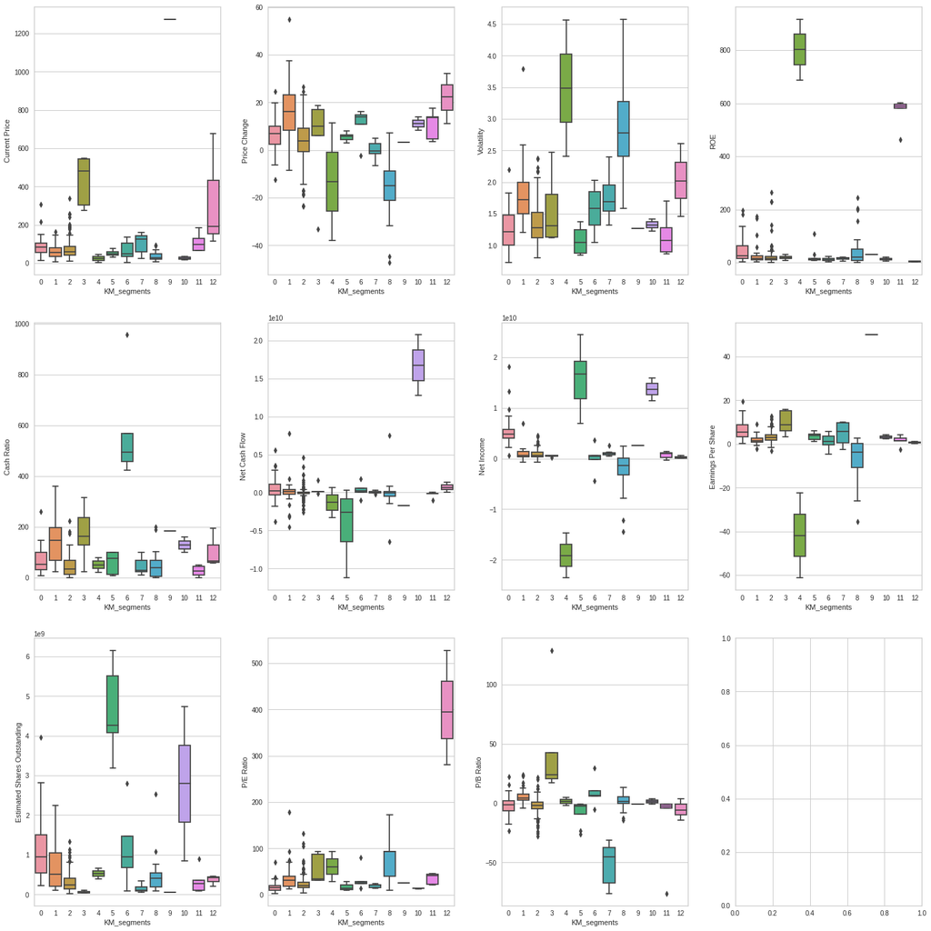

```python
# visualize distribution by cluster within each variable
fig, axes = plt.subplots(3, 4, figsize=(20, 20))
counter = 0

for ii in range(3):
    for jj in range(4):
        if counter < 11:
            sns.boxplot(
                ax=axes[ii][jj],
                data=df1,
                y=df1.columns[4+counter],
                x="KM_segments",
            )
            counter = counter + 1

fig.tight_layout(pad=3.0)
```

Many of the clusters seem to stand out from the others in just one or two variables. Some examples of this are cluster 12 having extremely high P/E ratio average, 7 having an extremely low P/B ratio average, 10 has very high cash flow, and 4 has very high ROE.

## Hierarchical Clustering

```python
hier_df = subset_scaled_df.copy()
```

```python
# list of distance metrics
distance_metrics = ["euclidean", "chebyshev", "mahalanobis", "cityblock"]

# list of linkage methods
linkage_methods = ["single", "complete", "average", "weighted"]

high_cophenet_corr = 0
high_dm_lm = [0, 0]

for dm in distance_metrics:
    for lm in linkage_methods:
        Z = linkage(hier_df, metric=dm, method=lm)
        c, coph_dists = cophenet(Z, pdist(hier_df))
        print(
            "Cophenetic correlation for {} distance and {} linkage is {}.".format(
                dm.capitalize(), lm, c
            )
        )
        if high_cophenet_corr < c:
            high_cophenet_corr = c
            high_dm_lm[0] = dm
            high_dm_lm[1] = lm
```

```
Cophenetic correlation for Euclidean distance and single linkage is 0.9232271494002922.
Cophenetic correlation for Euclidean distance and complete linkage is 0.7873280186580672.
Cophenetic correlation for Euclidean distance and average linkage is 0.9422540609560814.
Cophenetic correlation for Euclidean distance and weighted linkage is 0.8693784298129403.
Cophenetic correlation for Chebyshev distance and single linkage is 0.9062538164750717.
Cophenetic correlation for Chebyshev distance and complete linkage is 0.598891419111242.
Cophenetic correlation for Chebyshev distance and average linkage is 0.9338265528030499.
Cophenetic correlation for Chebyshev distance and weighted linkage is 0.9127355892367.
Cophenetic correlation for Mahalanobis distance and single linkage is 0.925919553052459.
Cophenetic correlation for Mahalanobis distance and complete linkage is 0.7925307202850002.
Cophenetic correlation for Mahalanobis distance and average linkage is 0.9247324030159736.
Cophenetic correlation for Mahalanobis distance and weighted linkage is 0.8708317490180428.
Cophenetic correlation for Cityblock distance and single linkage is 0.9334186366528577.
Cophenetic correlation for Cityblock distance and complete linkage is 0.7375328863205817.
Cophenetic correlation for Cityblock distance and average linkage is 0.9302145048594667.
Cophenetic correlation for Cityblock distance and weighted linkage is 0.731045513520281.
```

```python
print(
    "Highest cophenetic correlation is {}, which is obtained with {} distance and {} linkage.".format(
        high_cophenet_corr, high_dm_lm[0].capitalize(), high_dm_lm[1]
    )
)
```

```
Highest cophenetic correlation is 0.9422540609560814, which is obtained with Euclidean distance and average linkage.
```

Before moving on with Euclidean distance and average linkage, I want to check using ward and centroid linkage measures with Euclidean distance.

```python
linkage_methods = ["single", "complete", "average", "centroid", "ward", "weighted"]

high_cophenet_corr = 0
high_dm_lm = [0, 0]

for lm in linkage_methods:
    Z = linkage(hier_df, metric="euclidean", method=lm)
    c, coph_dists = cophenet(Z, pdist(hier_df))
    print("Cophenetic correlation for {} linkage is {}.".format(lm, c))
    if high_cophenet_corr < c:
        high_cophenet_corr = c
        high_dm_lm[0] = "euclidean"
        high_dm_lm[1] = lm
```

```
Cophenetic correlation for single linkage is 0.9232271494002922.
Cophenetic correlation for complete linkage is 0.7873280186580672.
Cophenetic correlation for average linkage is 0.9422540609560814.
Cophenetic correlation for centroid linkage is 0.9314012446828154.
Cophenetic correlation for ward linkage is 0.7101180299865353.
Cophenetic correlation for weighted linkage is 0.8693784298129403.
```

This confirms that the highest cophenetic correlation is with Euclidean distance and average linkage for our clustering.

##### Comparing Dendrograms

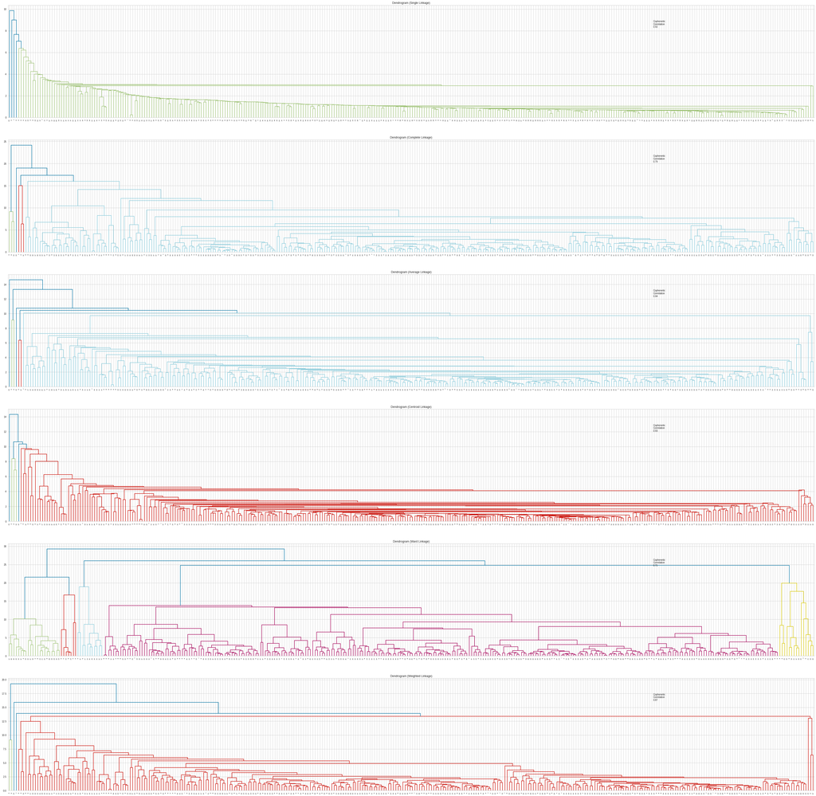

```python
# list of linkage methods
linkage_methods = ["single", "complete", "average", "centroid", "ward", "weighted"]

# Store results of cophenetic correlation calculation
compare_cols = ["Linkage", "Cophenetic Coefficient"]
compare = []

# Subplot image
fig, axs = plt.subplots(len(linkage_methods), 1, figsize=(60, 60))

# plotting dendrogram and calculating cophenetic correlation for each method in the list of linkages
for i, method in enumerate(linkage_methods):
    Z = linkage(hier_df, metric="euclidean", method=method)

    dendrogram(Z, ax=axs[i])
    axs[i].set_title(f"Dendrogram ({method.capitalize()} Linkage)")

    coph_corr, coph_dist = cophenet(Z, pdist(hier_df))
    axs[i].annotate(
        f"Cophenetic\nCorrelation\n{coph_corr:0.2f}",
        (0.80, 0.80),
        xycoords="axes fraction",
    )

    compare.append([method, coph_corr])
```

The dendrogram confirms that our best option is average linkage, which has a cophenetic correlation of .94. It also illustrates that the best number of clusters is 14, which we get from a line running through 6 on the y-axis. However, we can already see that we're going to have a similar situation as with the K-means clustering where we will have one cluster that has the majority of the Securities, with a few other much smaller clusters.

```python
# create and print a dataframe to compare cophenetic correlations for different linkage methods
df_cc = pd.DataFrame(compare, columns=compare_cols)
df_cc = df_cc.sort_values(by="Cophenetic Coefficient")
df_cc
```

|  | Linkage | Cophenetic Coefficient |
| --- | --- | --- |
| 4 | ward | 0.710118 |
| 1 | complete | 0.787328 |
| 5 | weighted | 0.869378 |
| 0 | single | 0.923227 |
| 3 | centroid | 0.931401 |
| 2 | average | 0.942254 |

```python
HCmodel = AgglomerativeClustering(n_clusters=14, affinity="euclidean", linkage="average")
HCmodel.fit(hier_df)
```

```
AgglomerativeClustering(linkage='average', n_clusters=14)
```

```python
# Complete the same process as with kmeans clustering, copy the original data and add the hierarchical clustering segments as a new column
df2 = df.copy()

hier_df["Hier_segments"] = HCmodel.labels_
df2["Hier_segments"] = HCmodel.labels_
```

```python
hier_cluster_profile = df2.groupby("Hier_segments").mean()
```

```python
hier_cluster_profile["count_in_each_segment"] = (
    df2.groupby("Hier_segments")["Security"].count().values
)
```

```python
hier_cluster_profile.style.highlight_max(color="lightgreen", axis=0)
```

| Hier_segments | Current Price | Price Change | Volatility | ROE | Cash Ratio | Net Cash Flow | Net Income | Earnings Per Share | Estimated Shares Outstanding | P/E Ratio | P/B Ratio | count_in_each_segment |
| --- | --- | --- | --- | --- | --- | --- | --- | --- | --- | --- | --- | --- |
| 0 | 33.045714 | -25.370461 | 3.099162 | 134.714286 | 42.428571 | -799925714.285714 | -6196564000.000000 | -16.158571 | 738990926.048571 | 91.065484 | -0.244701 | 7 |
| 1 | 108.304002 | 10.737770 | 1.165694 | 566.200000 | 26.600000 | -278760000.000000 | 687180000.000000 | 1.548000 | 349607057.720000 | 34.898915 | -16.851358 | 5 |
| 2 | 73.409926 | 4.531796 | 1.493778 | 25.146580 | 66.615635 | 69273648.208469 | 1356859508.143322 | 3.263274 | 447798338.366743 | 27.954482 | -2.035612 | 307 |
| 3 | 104.660004 | 16.224320 | 1.320606 | 8.000000 | 958.000000 | 592000000.000000 | 3669000000.000000 | 1.310000 | 2800763359.000000 | 79.893133 | 5.884467 | 1 |
| 4 | 46.672222 | 5.166566 | 1.079367 | 25.000000 | 58.333333 | -3040666666.666667 | 14848444444.444445 | 3.435556 | 4564959946.222222 | 15.596051 | -6.354193 | 9 |
| 5 | 152.564999 | 16.742017 | 2.314435 | 4.000000 | 130.000000 | 380861000.000000 | 133320500.000000 | 0.485000 | 317332352.950000 | 337.464244 | -9.935778 | 2 |
| 6 | 4.500000 | -38.101788 | 4.559815 | 687.000000 | 22.000000 | -3283000000.000000 | -14685000000.000000 | -22.430000 | 654703522.100000 | 28.407929 | -1.840528 | 1 |
| 7 | 44.470001 | 11.397804 | 2.405408 | 917.000000 | 80.000000 | 698000000.000000 | -23528000000.000000 | -61.200000 | 384444444.400000 | 93.089287 | 4.970809 | 1 |
| 8 | 675.890015 | 32.268105 | 1.460386 | 4.000000 | 58.000000 | 1333000000.000000 | 596000000.000000 | 1.280000 | 465625000.000000 | 528.039074 | 3.904430 | 1 |
| 9 | 1274.949951 | 3.190527 | 1.268340 | 29.000000 | 184.000000 | -1671386000.000000 | 2551360000.000000 | 50.090000 | 50935516.070000 | 25.453183 | -1.052429 | 1 |
| 10 | 513.004989 | -7.199128 | 1.800006 | 18.000000 | 277.000000 | -28580000.000000 | 532201000.000000 | 15.585000 | 34093273.660000 | 32.888681 | 29.904415 | 2 |
| 11 | 276.570007 | 6.189286 | 1.116976 | 30.000000 | 25.000000 | 90885000.000000 | 596541000.000000 | 8.910000 | 66951851.850000 | 31.040405 | 129.064585 | 1 |
| 12 | 34.450001 | 14.035095 | 1.226022 | 19.000000 | 162.000000 | 12747000000.000000 | 11420000000.000000 | 2.410000 | 4738589212.000000 | 14.294606 | 3.954975 | 1 |
| 13 | 16.830000 | 8.440722 | 1.418688 | 6.000000 | 99.000000 | 20764000000.000000 | 15888000000.000000 | 4.180000 | 845069512.200000 | 13.004785 | -0.938007 | 1 |

```python
for cl in df2["Hier_segments"].unique():
    print("In cluster {}, the following companies are present:".format(cl))
    print(df2[df2["Hier_segments"] == cl]["Security"].unique())
    print()
```

```
In cluster 2, the following companies are present:
['American Airlines Group' 'AbbVie' 'Abbott Laboratories'
 'Adobe Systems Inc' 'Analog Devices, Inc.' 'Archer-Daniels-Midland Co'
 'Ameren Corp' 'American Electric Power' 'AFLAC Inc'
 'American International Group, Inc.' 'Apartment Investment & Mgmt'
 'Assurant Inc' 'Arthur J. Gallagher & Co.' 'Akamai Technologies Inc'
 'Albemarle Corp' 'Alaska Air Group Inc' 'Allstate Corp'
 'Applied Materials Inc' 'AMETEK Inc' 'Affiliated Managers Group Inc'
 'Amgen Inc' 'Ameriprise Financial' 'American Tower Corp A'
 'AutoNation Inc' 'Anthem Inc.' 'Aon plc' 'Amphenol Corp' 'Arconic Inc'
 'Activision Blizzard' 'AvalonBay Communities, Inc.' 'Broadcom'
 'American Water Works Company Inc' 'American Express Co' 'Boeing Company'
 'Baxter International Inc.' 'BB&T Corporation' 'Bard (C.R.) Inc.'
 'Baker Hughes Inc' 'BIOGEN IDEC Inc.' 'The Bank of New York Mellon Corp.'
 'Ball Corp' 'Bristol-Myers Squibb' 'Boston Scientific' 'BorgWarner'
 'Boston Properties' 'Caterpillar Inc.' 'Chubb Limited' 'CBRE Group'
 'Crown Castle International Corp.' 'Carnival Corp.' 'Celgene Corp.'
 'CF Industries Holdings Inc' 'Citizens Financial Group' 'Church & Dwight'
 'C. H. Robinson Worldwide' 'CIGNA Corp.' 'Cincinnati Financial'
 'Comerica Inc.' 'CME Group Inc.' 'Cummins Inc.' 'CMS Energy'
 'Centene Corporation' 'CenterPoint Energy' 'Capital One Financial'
 'Cabot Oil & Gas' 'The Cooper Companies' 'CSX Corp.' 'CenturyLink Inc'
 'Cognizant Technology Solutions' 'Citrix Systems' 'CVS Health'
 'Chevron Corp.' 'Concho Resources' 'Dominion Resources' 'Delta Air Lines'
 'Du Pont (E.I.)' 'Deere & Co.' 'Discover Financial Services'
 'Quest Diagnostics' 'Danaher Corp.' 'The Walt Disney Company'
 'Discovery Communications-A' 'Discovery Communications-C'
 'Delphi Automotive' 'Digital Realty Trust' 'Dun & Bradstreet'
 'Dover Corp.' 'Dr Pepper Snapple Group' 'Duke Energy' 'DaVita Inc.'
 'eBay Inc.' 'Ecolab Inc.' 'Consolidated Edison' 'Equifax Inc.'
 "Edison Int'l" 'Eastman Chemical' 'EOG Resources' 'Equinix'
 'Equity Residential' 'EQT Corporation' 'Eversource Energy'
 'Essex Property Trust, Inc.' 'E*Trade' 'Eaton Corporation'
 'Entergy Corp.' 'Edwards Lifesciences' 'Exelon Corp.' "Expeditors Int'l"
 'Expedia Inc.' 'Extra Space Storage' 'Fastenal Co'
 'Fortune Brands Home & Security' 'FirstEnergy Corp'
 'Fidelity National Information Services' 'Fiserv Inc' 'FLIR Systems'
 'Fluor Corp.' 'Flowserve Corporation' 'FMC Corporation'
 'Federal Realty Investment Trust' 'First Solar Inc'
 'Frontier Communications' 'General Dynamics'
```

[output cut: 86 more lines]

```

In cluster 6, the following companies are present:
['Chesapeake Energy']

In cluster 10, the following companies are present:
['Chipotle Mexican Grill' 'Intuitive Surgical Inc.']

In cluster 3, the following companies are present:
['Facebook']

In cluster 12, the following companies are present:
['Intel Corp.']

In cluster 9, the following companies are present:
['Priceline.com Inc']
```

```python
df2.groupby(["Hier_segments", "GICS Sector"])['Security'].count()
```

```
Hier_segments  GICS Sector
0              Energy                          6
               Materials                       1
1              Consumer Discretionary          1
               Consumer Staples                2
               Financials                      1
               Industrials                     1
2              Consumer Discretionary         35
               Consumer Staples               16
               Energy                         21
               Financials                     44
               Health Care                    37
               Industrials                    52
               Information Technology         29
               Materials                      19
               Real Estate                    27
               Telecommunications Services     3
               Utilities                      24
3              Information Technology          1
4              Consumer Discretionary          1
               Consumer Staples                1
               Energy                          1
               Financials                      3
               Health Care                     1
               Telecommunications Services     2
5              Health Care                     1
               Information Technology          1
6              Energy                          1
7              Energy                          1
8              Consumer Discretionary          1
9              Consumer Discretionary          1
10             Consumer Discretionary          1
               Health Care                     1
11             Information Technology          1
12             Information Technology          1
13             Financials                      1
Name: Security, dtype: int64
```

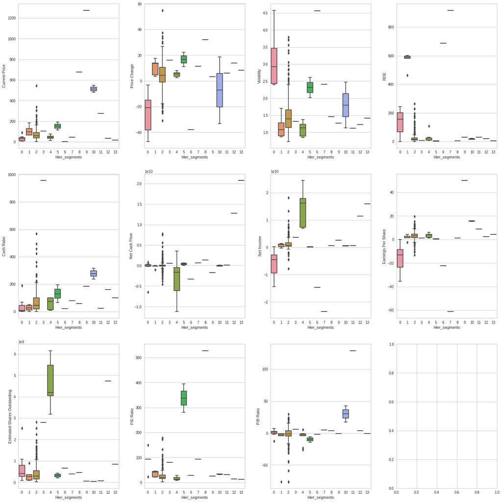

```python
fig, axes = plt.subplots(3, 4, figsize=(20, 20))
counter = 0

for ii in range(3):
    for jj in range(4):
        if counter < 11:
            sns.boxplot(
                ax=axes[ii][jj],
                data=df2,
                y=df2.columns[4+counter],
                x="Hier_segments",
            )
            counter = counter + 1

fig.tight_layout(pad=3.0)
```

While the hierarchical clustering produced a somewhat similar dynamic with certain clusters standing out from all others on one variable, this clustering produced lots of extremely small clusters (only 1 or 2 data points), so instead of whole clusters standing out, it seems to have turned individual data points that stood out on one variable into their own cluster.

## K-means vs Hierarchical Clustering

You compare several things, like:

- Which clustering technique took less time for execution?
- Which clustering technique gave you more distinct clusters, or are they the same?
- How many observations are there in the similar clusters of both algorithms?
- How many clusters are obtained as the appropriate number of clusters from both algorithms?

You can also mention any differences or similarities you obtained in the cluster profiles from both the clustering techniques.

The K-means clustering seemed to be easier for me, simply because I didn't need to analyze the dendrograms which took a while given the number of data points and multiple options which that provided.

I had more clusters in the hierarchical clustering, but also had the issue more severely of most data points being grouped into one individual cluster. This issue was still present in the k-means method, but not nearly as bad.

Both algorithms seemed to be heavily influenced by the large outliers in the dataset, which led to either individual observation clusters, or else clusters with very few observations, while the high majority of observations were in a small number of clusters because they were much more similar compared to the outlier points. This overall seems to be a weakness of this approach.

## Actionable Insights and Recommendations

For a model recommendation, I recommend moving forward by using the clusters provided by the k-means algorithm. This model has observations more evenly distributed between the clusters, so we have a few denser groups that we can use to draw conclusions and gain insights, whereas the clusters from the hierarchical cluster algorithm are mostly made up of 1 or 2 data points, so all we can learn about the grouping is which data points are outliers on a given variable.